# Praca domowa 2

Szymon Domański

## Dane

Dane wykorzystane w Pracy domowej 2 dotyczą wyników egzaminów z 3 umiejętności: czytania, pisania i operacji matematycznych. Dodatkowo dostępne są podstawowe informacje o studentach i ich rodzicach. Opis wszystkich kolumn znajduje się również w pliku `README.md`.

| Zmienna | Opis |
| --- | --- |
| **gender** | płeć |
| **race.ethnicity** | pochodzenie etniczne |
| **parental.level.of.education** | wykształcenie rodziców |
| **lunch** | jaki obiad jedli uczniowie w dniu egzaminu |
| **test.preparation.course** | czy uczeń odbył kurs przygotowujący |
| **math.score** | wynik egzaminu z matematyki |
| **reading.score** | wynik egzaminu z czytania |
| **writing.score** | wynik egzaminu z pisania |

## Zadanie 1

Jak wyglądają rozkłady wyników uczniów z trzech przedmiotów (matematyka, czytanie, pisanie)?

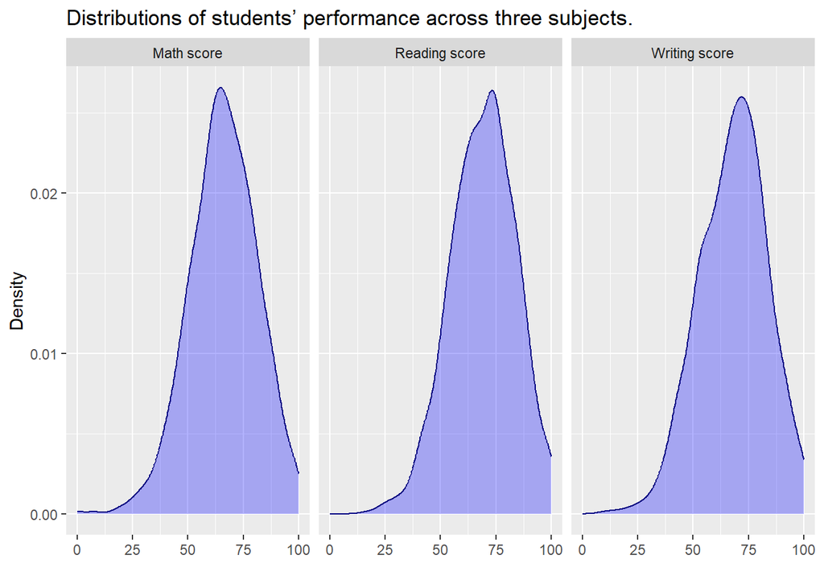

```r
df %>%
  select(math.score:writing.score) %>%
  pivot_longer(cols = math.score:writing.score, names_to = "test.type", values_to = "score") %>%
  ggplot(aes(x = score)) +
  geom_density(color = "navy", fill = 'blue', alpha = 0.3) +
  facet_wrap(~test.type, labeller = labeller(
               test.type = c(
                 "math.score" = "Math score",
                 "reading.score" = "Reading score",
                 "writing.score" = "Writing score"
               ))) +
  labs(title = "Distributions of students’ performance across three subjects.",
       x = "",
       y = "Density")
```

## Zadanie 2

Czy istnieje zauważalna różnica w wynikach między uczniami i uczennicami?

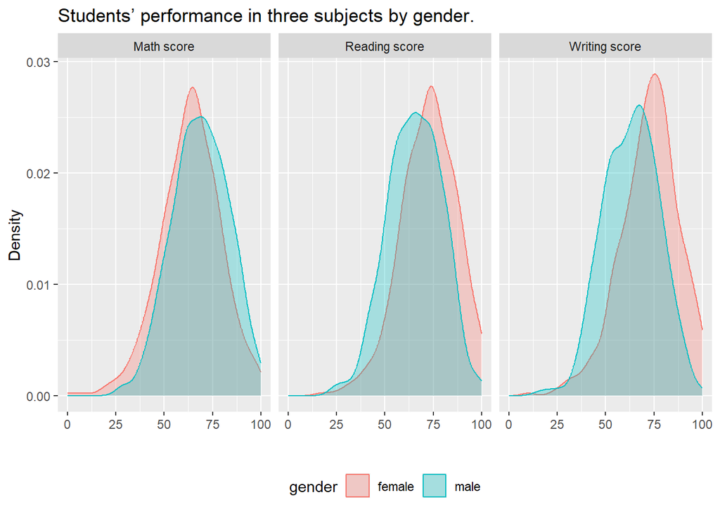

```r
df %>%
  select(gender, math.score:writing.score) %>%
  pivot_longer(cols = math.score:writing.score,names_to = "test_type", values_to = "result" ) %>%
  ggplot(aes(x = result, color = gender, fill = gender)) +
  geom_density(alpha = 0.3) +
  facet_wrap(~test_type, labeller = labeller(
               test_type = c(
                 "math.score" = "Math score",
                 "reading.score" = "Reading score",
                 "writing.score" = "Writing score"
               ))) +
  labs(title = "Students’ performance in three subjects by gender.",
       x = "",
       y = "Density"
       ) +
  theme(legend.position = "bottom")
```

**Komentarz: Z wykresu możemy zauważyć, mężczyźni są lepsi z matematyki, natomiast kobiety są lepsze z czytania i pisania.**

## Zadanie 3

Czy uczniowie, którzy ukończyli kurs przygotowawczy, osiągają lepsze wyniki niż pozostali?

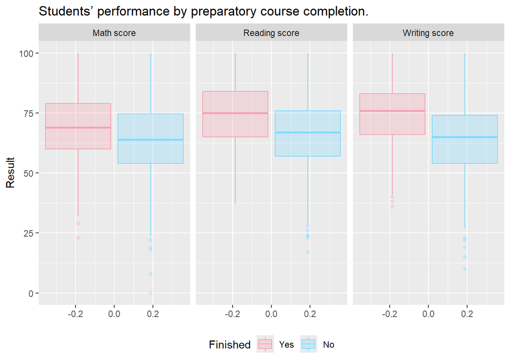

```r
df %>%
  select(test.preparation.course, math.score:writing.score) %>%
  pivot_longer(cols = math.score:writing.score,names_to = "test_type", values_to = "result" ) %>%
  ggplot(aes(y = result, color = test.preparation.course, fill = test.preparation.course)) +
  geom_boxplot(alpha = 0.3) +
  facet_wrap(~test_type, labeller = labeller(
               test_type = c(
                 "math.score" = "Math score",
                 "reading.score" = "Reading score",
                 "writing.score" = "Writing score"
               ))) +
  theme(legend.position = "bottom") +
  labs(title = "Students’ performance by preparatory course completion.",
       y = "Result",
       fill = "Finished",
       color = "Finished") +
  scale_fill_manual(values = c("completed" = "#F4A3B4", "none" = "#7FDBFF"),
                    labels = c("completed" = "Yes", "none" = 'No')) +
  scale_color_manual(values = c("completed" = "#F4A3B4", "none" = "#7FDBFF"),
                     labels = c("completed" = "Yes", "none" = 'No'))
```

**Komentarz: Tak, widać to jasno z wykresów.**

## Zadanie 4

Jaki jest związek między poziomem wykształcenia rodziców a średnimi wynikami uczniów?

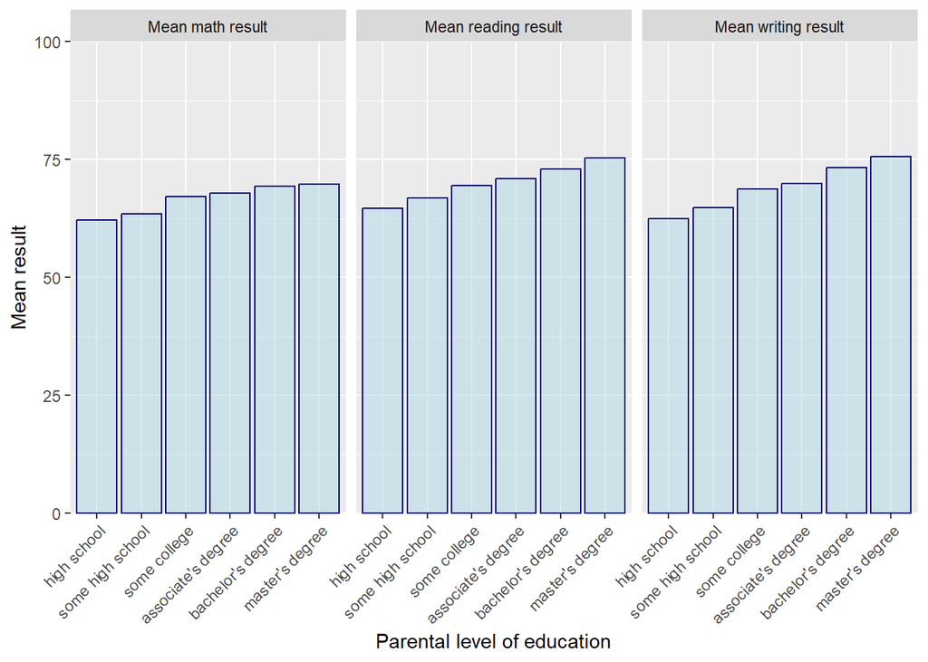

```r
df %>%
  group_by(parental.level.of.education) %>%
  summarize(mean_math = mean(math.score), mean_reading = mean(reading.score),
            mean_writing = mean(writing.score)) %>%
  pivot_longer(cols =mean_math:mean_writing, names_to = 'test_type',
               values_to = 'mean_result') %>%
  ggplot(aes(x = forcats::fct_reorder(parental.level.of.education, mean_result), y = mean_result)) +
  geom_col(color = 'navy', fill = 'lightblue', alpha = 0.5) +
  facet_wrap(~test_type, labeller = labeller(
               test_type = c(
                 "mean_math" = "Mean math result",
                 "mean_reading" = "Mean reading result",
                 "mean_writing" = "Mean writing result"
               ))) +
  scale_y_continuous(expand = c(0,0), limits = c(0,100)) +
  labs(x = "Parental level of education", y = "Mean result") +
  theme(legend.position = 'bottom', legend.title = element_text(size = 15)) +
  scale_x_discrete(guide = guide_axis(angle = 45))
```

## Zadanie 5

Czy płeć i wykształcenie rodzica wpływa na wynik z matematyki?

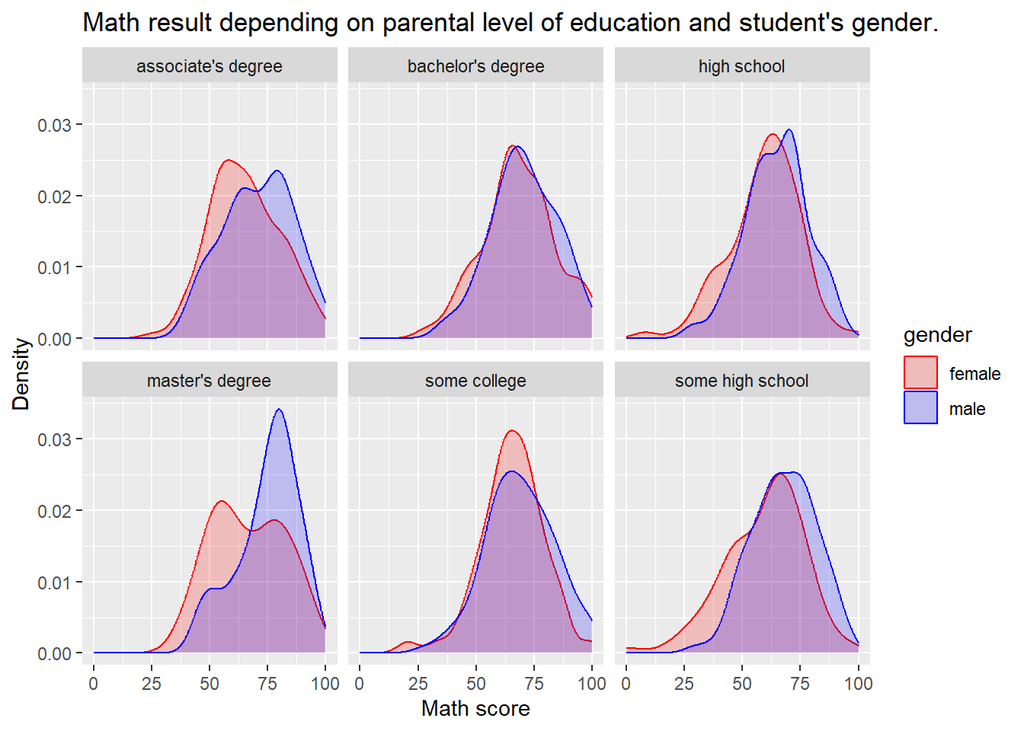

```r
df %>%
  select(gender, parental.level.of.education, math.score) %>%
  pivot_longer(cols = math.score, values_to = "math.score") %>%
  select(gender, parental.level.of.education, math.score) %>%
  ggplot(aes(x = math.score, fill = gender, color = gender)) +
  geom_density(alpha = 0.2) +
  facet_wrap(~parental.level.of.education) +
  scale_fill_manual(values = c('red', 'blue')) +
  scale_color_manual(values = c('red', 'blue')) +
  labs(title = "Math result depending on parental level of education and student's gender.",
       x = "Math score",
       y = "Density")
```

**Komentarz: Obie te cechy mają wpływ na wynik z matematyki, szczególnie widać to na wykresie, gdzie poziom wykształcenia rodziców to poziom magisterski.**

## Zadanie 6

Czy istnieje zależność między wynikami z matematyki a wynikami z czytania lub pisania?

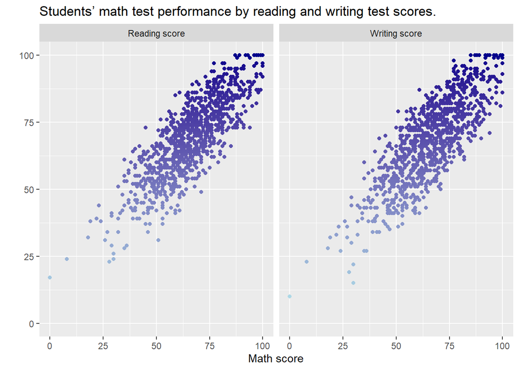

```r
df %>%
  select(math.score:writing.score) %>%
  pivot_longer(cols = reading.score:writing.score, names_to = "test.type", values_to = "score") %>%
  ggplot(aes(x = math.score, y = score, color = score)) +
    scale_color_gradient(low = 'lightblue', high = 'darkblue') +
  geom_point() +
  facet_wrap(~test.type, labeller = labeller(
               test.type = c(
                 "reading.score" = "Reading score",
                 "writing.score" = "Writing score"
               ))) +
  scale_y_continuous(expand = c(0,0), limits = c(-5,105)) +
  scale_x_continuous(expand = c(0,0), limits = c(-5,105)) +
  labs(title = "Students’ math test performance by reading and writing test scores.",
       x = "Math score",
       y = "") +
  theme(legend.position = "None")
```

**Komentarz: Istnieje wyraźna zależność między wynikami z matematyki a wynikami z czytania i pisania. Widzimy to przez punkty układające się wzdłuź prostej y = x.**